# Stroop Effect Exploration By Mehdi Jafari

## Introduction

In psychology, the Stroop effect is a demonstration of interference in the reaction time of a task. When the name of a color (e.g., “blue”, “green”, or “red”) is printed in a color that is not denoted by the name (e.g., the word “red” printed in blue ink instead of red ink), naming the color of the word takes longer and is more prone to errors than when the color of the ink matches the name of the color.

In a Stroop task, participants are presented with a list of words, with each word displayed in a color of ink. The participant’s task is to say out loud the color of the ink in which the word is printed. The task has two conditions: a congruent words condition, and an incongruent words condition. In the congruent words condition, the words being displayed are color words whose names match the colors in which they are printed: for example, RED , BLUE In the incongruent words condition, the words displayed are color words whose names do not match the colors in which they are printed: for example, PURPLE, ORANGE. In each case, we measure the time it takes to name the ink colors in equally-sized lists. Each participant will go through and record a time from each condition.

## Questions

1- What is our independent variable? What is our dependent variable?

- dependent variable is the time that takes each participant to name the ink color
- independent variable is the congruent or incongruent of shown words

2- What is an appropriate set of hypotheses for this task? What kind of statistical test do you expect to perform? Justify your choices.

Null hypotheses => There is no difference in population means of response time under incongruent and congruent scenarios, which can be mathematically represented as:

µi = µ0

Alternative hypotheses => population means of response time under incongruent condition is greater than congruent condition’s, which can be represented mathematically as:

µi > µ0

Since the sample size is less than 30 and we don’t have the standard deviation of the population then we should use t test statistics. If we had standard deviation of population and the sample size was greater than 30 we would go with z-test.

- H0 –> µi = µ0
- Ha –> µi > µ0

Confidence level is 95% then α is 0.05.

T critical value = 1.714

3- Report some descriptive statistics regarding this dataset. Include at least one measure of central tendency and at least one measure of variability

```
##    Congruent      Incongruent
##  Min.   : 8.63   Min.   :15.69
##  1st Qu.:11.90   1st Qu.:18.72
##  Median :14.36   Median :21.02
##  Mean   :14.05   Mean   :22.02
##  3rd Qu.:16.20   3rd Qu.:24.05
##  Max.   :22.33   Max.   :35.26
```

```
## [1] "Standard Deviation of Congurent variable : 3.5593579576452"
```

```
## [1] "Standard Deviation of Incongruent variable : 4.79705712246914"
```

```
## [1] "Variance of Congurent variable : 12.6690290706522"
```

```
## [1] "Variance of Incongruent variable : 23.0117570362319"
```

4- Provide one or two visualizations that show the distribution of the sample data. Write one or two sentences noting what you observe about the plot or plots .

As it is depicted in the following histograms, most participants completed the incongruent word set between 16-25 Seconds while the congruent word set took them between 11-17 seconds. It shows the congruent word set takes less time than the incongruent word set.

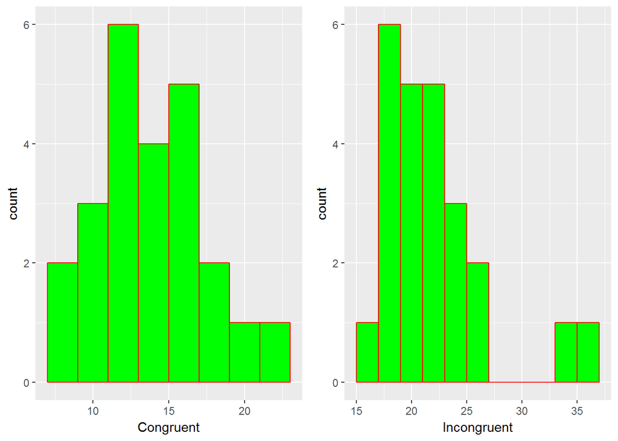

5- Now, perform the statistical test and report your results. What is your confidence level and your critical statistic value? Do you reject the null hypothesis or fail to reject it? Come to a conclusion in terms of the experiment task. Did the results match up with your expectations?

This is a dependent-sample and a pre-test, post-test scenario.

Since the t-statistics falls in critical region which is way bigger than 1.714(t-critical value for α=0.05) we reject the null hypotheses.

P-value is less than .05 Which means the two sample populations are statistically significant.

R2 is equal to 73% which means 73% of the difference is due to the incongruent treatment.

From the experiment we saw that there is a significant difference between the mean response times for the congruent and incongruent tests. With the help of the t-test performed we can infer that there is a significant difference in the time taken for the two tests in the population. This result matched with my expectation based on the Stroop test I have taken.